# ADA_Final_Project

Abel Abebe

2025-12-01

# Introduction

Gastroesophageal cancer (GEC) which includes esophageal, gastroesophageal junction (GEJ), and gastric is an aggressive malignancy with poor prognosis. Delays in diagnosis and differences in access to guideline-concordant care may contribute to disparities in stage at diagnosis and survival across sociodemographic groups. Prior literature suggests that race and sex may influence cancer outcomes, but evidence in single-center contemporary cohorts of GEC is limited.

For my Advanced Data Analysis (ADA) final project, I used data from a retrospective cohort of patients with GEC treated at Siteman Cancer Center to explore whether there are racial and sex differences in:

1. Clinical stage at diagnosis (early [stage I–II] vs late [stage III–IV]), and
2. Overall survival from time of diagnosis.

**Research questions**

- Are Black patients more likely than White patients to be diagnosed at late stage (III–IV vs I–II)?
- Are there sex differences (female vs male) in late-stage diagnosis?
- Are there racial and sex differences in overall survival after adjusting for age and stage at diagnosis?

# Methods

## Data source and study population

I analyzed a retrospective cohort of 150 adult patients with GEC who were treated at Siteman Cancer Center. The analytic dataset was exported from REDCap and includes patients with esophageal adenocarcinoma (EAC), esophageal squamous cell carcinoma (ESSC), GEJ cancers, and gastric adenocarcinoma.

The dataset used for the project is not shared in the GitHub repository because it contains patient-level clinical information.

## Key variables

- **Outcomes**
  - **Stage at diagnosis (binary)**: early stage (I–II) vs late stage (III–IV), based on clinical staging at diagnosis.
  - **Overall survival time (months)**: calculated from date of diagnosis to date of death or last follow-up.
  - **Event indicator**: 1 = died during follow-up, 0 = alive or lost to follow-up at last known contact.
- **Main predictors**
  - **Race**: White vs Black or African American (patients with unknown race were excluded from regression models involving race).
  - **Sex**: male vs female.
- **Covariates for logistic regression (stage at diagnosis)**
  - Age at diagnosis (years, continuous)
  - History of Barrett’s esophagus (yes / no / unknown)
  - History of tobacco use (yes / no)
  - History of *H. pylori* infection (yes / no / unknown)
- **Covariates for Cox model (overall survival)**
  - Age at diagnosis (years, continuous)
  - Stage at diagnosis (late [III–IV] vs early [I–II])
  - Race (White vs Black) and sex (female vs male)

## Statistical analysis

All analyses were conducted in R using R Markdown.

1. **Descriptive analyses (Table 1)**
   - I summarized sociodemographic and clinical characteristics of the cohort overall, including age, BMI, sex, race, history of Barrett’s esophagus, tobacco use, *H. pylori* infection, cancer type, stage at diagnosis, chemotherapy, radiation, recurrence, and vital status.
2. **Stage at diagnosis (logistic regression)**
   - I created a binary variable for stage at diagnosis: early (I–II) vs late (III–IV). Patients with unknown/missing stage were excluded from regression models.
   - I first fit separate **univariable logistic regression models** with late vs early stage as the outcome and race or sex as the predictor.
   - I then fit a **multivariable logistic regression model** with late vs early stage as the outcome and race and sex as the main predictors, adjusting for age, history of Barrett’s esophagus, tobacco use, and *H. pylori* infection.
   - I reported odds ratios (ORs) with 95% confidence intervals (CIs) and p-values (Table 2).
3. **Overall survival (Kaplan–Meier and Cox models)**
   - I calculated survival time in months from diagnosis to death or last follow-up and created an event indicator (1 = death, 0 = alive or lost to follow-up).
   - I described overall survival using Kaplan–Meier (KM) curves for the whole cohort and stratified by race and sex, and compared curves using log-rank tests.
   - For regression, I restricted to patients with known race (White or Black) and known stage (I–IV).
   - I fit a **multivariable Cox proportional hazards model** with overall survival as the outcome and race and sex as the main predictors, adjusting for age and stage at diagnosis (late vs early).
   - I reported hazard ratios (HRs) with 95% CIs and p-values (Table 3) and checked the proportional hazards assumption using Schoenfeld residuals.

All analyses are exploratory and based on a relatively small, single-center cohort, so results should be interpreted cautiously.

### Packages and libraries

```r
# install.packages("pacman")
pacman::p_load(
  tidyverse,   # data cleaning, recoding, tables
  table1,      # Table 1
  survival,    # Surv(), coxph(), survfit()
  survminer,   # ggsurvplot()
  broom,       # tidy() for model output
  lubridate    # working with dates
)
```

### Gastroesophageal cancer data

```r
# Read in gastroesophageal cancer data from my REDCap export
gec <- read_csv("RetrospectiveStudyOf_DATA.csv")
# Check the variable names in my gastroesophageal cancer dataset for my ADA final project

colnames(gec)
```

```
##  [1] "record_id"              "age_at_death_follow_up" "sex"
##  [4] "race"                   "hx_of_barretts"         "tobacco_yn"
##  [7] "h_pylori_yn"            "bmi_at_dx"              "date_at_diagnosis"
## [10] "gastroeso_cancer_type"  "stage_at_diagnosis"     "chemo_received"
## [13] "name_chemo_option"      "radiation_therapy_yn"   "recurrence"
## [16] "status"                 "date_last_fu"           "date_of_death"
## [19] "date_last_follow"       "cause_of_death"
```

### Variables for my ADA final project

```r
# Recode key variables (demographics, risk factors, cancer type, stage, treatment, status)

gec <- gec %>%
mutate(
# Age and BMI

# rename age variable to 'age'
age = age_at_death_follow_up,
# convert BMI from character to numeric
bmi = as.numeric(bmi_at_dx),

# Sex
sex_f = factor(
  sex,
  levels = c(1, 2),
  labels = c("Male", "Female")
),

# Race
race_f = factor(
  race,
  levels = c(1, 2, 5),
  labels = c("White",
             "Black or African American",
             "Unknown")
),

# History of Barrett esophagus
barretts_f = case_when(
  hx_of_barretts == 1 ~ "Yes",
  hx_of_barretts == 0 ~ "No",
  hx_of_barretts == 9 ~ "Unknown",
  TRUE ~ NA_character_
),
barretts_f = factor(barretts_f,
                    levels = c("No", "Yes", "Unknown")),

# History of tobacco use
tobacco_f = case_when(
  tobacco_yn == 1 ~ "Yes",
  tobacco_yn == 0 ~ "No",
  tobacco_yn == 9 ~ "Unknown",
  TRUE ~ NA_character_
),
tobacco_f = factor(tobacco_f,
                   levels = c("No", "Yes", "Unknown")),

# History of H. pylori infection
hpylori_f = case_when(
  h_pylori_yn == 1 ~ "Yes",
  h_pylori_yn == 0 ~ "No",
  h_pylori_yn == 9 ~ "Unknown",
  TRUE ~ NA_character_
),
hpylori_f = factor(hpylori_f,
                   levels = c("No", "Yes", "Unknown")),

# Gastroesophageal cancer type
cancer_type_f = case_when(
  gastroeso_cancer_type == 1 ~ "Esophageal adenocarcinoma",
  gastroeso_cancer_type == 2 ~ "GEJ adenocarcinoma",
  gastroeso_cancer_type == 3 ~ "Distal esophageal/GEJ adenocarcinoma",
  gastroeso_cancer_type == 4 ~ "Esophageal squamous cell carcinoma",
  gastroeso_cancer_type == 5 ~ "Gastric adenocarcinoma",
  gastroeso_cancer_type == 6 ~ "GEJ/gastric adenocarcinoma",
  gastroeso_cancer_type == 7 ~ "Other",
  gastroeso_cancer_type == 9 ~ "Unknown",
  TRUE ~ NA_character_
),
cancer_type_f = factor(cancer_type_f),

# Clinical stage at diagnosis
stage_f = case_when(
  stage_at_diagnosis == 1 ~ "Stage I",
  stage_at_diagnosis == 2 ~ "Stage II",
  stage_at_diagnosis == 3 ~ "Stage III",
  stage_at_diagnosis == 4 ~ "Stage IV",
  TRUE ~ NA_character_        # this includes 9 = Unknown
),
stage_f = factor(stage_f,
                 levels = c("Stage I", "Stage II", "Stage III", "Stage IV")),

# Chemotherapy received
chemo_f = case_when(
  chemo_received == 1 ~ "Yes",
  chemo_received == 2 ~ "No",
  chemo_received == 9 ~ "Unknown",
  TRUE ~ NA_character_
),
chemo_f = factor(chemo_f,
                 levels = c("No", "Yes", "Unknown")),

# Chemotherapy regimen
chemo_regimen_f = case_when(
  name_chemo_option == 1 ~ "Carboplatin + Paclitaxel",
  name_chemo_option == 2 ~ "FOLFOX",
  name_chemo_option == 3 ~ "5-FU",
  name_chemo_option == 4 ~ "FLOT",
  name_chemo_option == 5 ~ "FOLFIRI",
  name_chemo_option == 6 ~ "Other",
  name_chemo_option == 9 ~ "Unknown",
  TRUE ~ NA_character_
),
chemo_regimen_f = factor(chemo_regimen_f),

# Radiation therapy
radiation_f = case_when(
  radiation_therapy_yn == 1 ~ "Yes",
  radiation_therapy_yn == 0 ~ "No",
  radiation_therapy_yn == 9 ~ "Unknown",
  TRUE ~ NA_character_
),
radiation_f = factor(radiation_f,
                     levels = c("No", "Yes", "Unknown")),

# Recurrence
recurrence_f = case_when(
  recurrence == 1 ~ "Yes",
  recurrence == 2 ~ "No",
  recurrence == 3 ~ "Unknown",
  TRUE ~ NA_character_
),
recurrence_f = factor(recurrence_f,
                      levels = c("No", "Yes", "Unknown")),

# Vital status at last follow-up
status_f = case_when(
  status == 1 ~ "Alive",
  status == 2 ~ "Deceased",
  status == 9 ~ "Unknown",
  TRUE ~ NA_character_
),
status_f = factor(status_f,
                  levels = c("Alive", "Deceased", "Unknown"))

)
```

```r
# Check recoded variables in my gastroesophageal cancer dataset for my ADA final project

summary(gec[, c(
"age", "bmi",
"sex_f", "race_f",
"barretts_f", "tobacco_f", "hpylori_f",
"cancer_type_f", "stage_f",
"chemo_f", "chemo_regimen_f",
"radiation_f", "recurrence_f",
"status_f"
)])
```

```
##       age             bmi           sex_f                           race_f
##  Min.   :28.00   Min.   :13.79   Male  :119   White                    :130
##  1st Qu.:58.00   1st Qu.:24.12   Female: 31   Black or African American: 19
##  Median :67.00   Median :27.90                Unknown                  :  1
##  Mean   :64.67   Mean   :28.83
##  3rd Qu.:72.00   3rd Qu.:32.87
##  Max.   :98.00   Max.   :53.85
##
##    barretts_f   tobacco_f     hpylori_f
##  No     :47   No     : 45   No     :66
##  Yes    :47   Yes    :105   Yes    :11
##  Unknown:56   Unknown:  0   Unknown:73
##
##
##
##
##                               cancer_type_f      stage_f      chemo_f
##  Distal esophageal/GEJ adenocarcinoma:15    Stage I  : 8   No     : 14
##  Esophageal adenocarcinoma           :59    Stage II :15   Yes    :132
##  Esophageal squamous cell carcinoma  :13    Stage III:47   Unknown:  4
##  Gastric adenocarcinoma              :20    Stage IV :69
##  GEJ adenocarcinoma                  :38    NA's     :11
##  GEJ/gastric adenocarcinoma          : 5
##
##                  chemo_regimen_f  radiation_f  recurrence_f     status_f
##  5-FU                    : 4     No     :78   No     :118   Alive   :88
##  Carboplatin + Paclitaxel:45     Yes    :70   Yes    : 23   Deceased:38
##  FLOT                    :24     Unknown: 2   Unknown:  9   Unknown :24
##  FOLFOX                  :56
##  Other                   : 2
##  Unknown                 : 1
##  NA's                    :18
```

### Clean analytic dataset

```r
# Create an analytic dataset for my ADA final project with only variables I need

gec_analytic <- gec %>%
dplyr::select(
record_id,
age, bmi,
sex_f, race_f,
barretts_f, tobacco_f, hpylori_f,
cancer_type_f, stage_f,
chemo_f, chemo_regimen_f,
radiation_f, recurrence_f,
status_f,
date_at_diagnosis,
date_last_fu, date_of_death, date_last_follow
)
```

# Results

## Descriptive characteristics

Table 1 summarizes sociodemographic and clinical characteristics of the 150 patients in the cohort. The mean age at diagnosis was about 65 years, and median BMI was approximately 28. Most patients were male (79%) and White (87%); 13% were Black or African American and 1 patient had unknown race. Tobacco use history was common (70%). Nearly half of the cohort had *H. pylori* status recorded as unknown. The most common cancer types were EAC and GEJ adenocarcinoma. Almost half of patients (46%) were diagnosed at stage IV, and the majority received chemotherapy.

### Labels for Table 1 variables

```r
# Add variable labels for my ADA final project Table 1

label(gec_analytic$age) <- "Age at diagnosis (years)"
label(gec_analytic$bmi) <- "BMI at diagnosis (kg/m^2)"
label(gec_analytic$sex_f) <- "Sex"
label(gec_analytic$race_f) <- "Race"
label(gec_analytic$barretts_f) <- "History of Barrett's esophagus"
label(gec_analytic$tobacco_f) <- "History of tobacco use"
label(gec_analytic$hpylori_f) <- "History of H. pylori infection"
label(gec_analytic$cancer_type_f) <- "Gastroesophageal cancer type"
label(gec_analytic$stage_f) <- "Clinical stage at diagnosis"
label(gec_analytic$chemo_f) <- "Chemotherapy received"
label(gec_analytic$chemo_regimen_f) <- "Chemotherapy regimen"
label(gec_analytic$radiation_f) <- "Radiation therapy received"
label(gec_analytic$recurrence_f) <- "Recurrence"
label(gec_analytic$status_f) <- "Patient status"
```

## Table 1: Overall characteristics

```r
# Table 1: Overall sociodemographic and clinical characteristics
table1(
~ age + bmi +
sex_f + race_f +
barretts_f + tobacco_f + hpylori_f +
cancer_type_f + stage_f +
chemo_f + chemo_regimen_f +
radiation_f + recurrence_f +
status_f,
data = gec_analytic,
overall = "Total",
rowlabelhead = "Variable"
)
```

| Variable | Total (N=150) |
| --- | --- |
| Age at diagnosis (years) |  |
| Mean (SD) | 64.7 (11.5) |
| Median [Min, Max] | 67.0 [28.0, 98.0] |
| BMI at diagnosis (kg/m^2) |  |
| Mean (SD) | 28.8 (7.12) |
| Median [Min, Max] | 27.9 [13.8, 53.9] |
| Sex |  |
| Male | 119 (79.3%) |
| Female | 31 (20.7%) |
| Race |  |
| White | 130 (86.7%) |
| Black or African American | 19 (12.7%) |
| Unknown | 1 (0.7%) |
| History of Barrett's esophagus |  |
| No | 47 (31.3%) |
| Yes | 47 (31.3%) |
| Unknown | 56 (37.3%) |
| History of tobacco use |  |
| No | 45 (30.0%) |
| Yes | 105 (70.0%) |
| Unknown | 0 (0%) |
| History of H. pylori infection |  |
| No | 66 (44.0%) |
| Yes | 11 (7.3%) |
| Unknown | 73 (48.7%) |
| Gastroesophageal cancer type |  |
| Distal esophageal/GEJ adenocarcinoma | 15 (10.0%) |
| Esophageal adenocarcinoma | 59 (39.3%) |
| Esophageal squamous cell carcinoma | 13 (8.7%) |
| Gastric adenocarcinoma | 20 (13.3%) |
| GEJ adenocarcinoma | 38 (25.3%) |
| GEJ/gastric adenocarcinoma | 5 (3.3%) |
| Clinical stage at diagnosis |  |
| Stage I | 8 (5.3%) |
| Stage II | 15 (10.0%) |
| Stage III | 47 (31.3%) |
| Stage IV | 69 (46.0%) |
| Missing | 11 (7.3%) |
| Chemotherapy received |  |
| No | 14 (9.3%) |
| Yes | 132 (88.0%) |
| Unknown | 4 (2.7%) |
| Chemotherapy regimen |  |
| 5-FU | 4 (2.7%) |
| Carboplatin + Paclitaxel | 45 (30.0%) |
| FLOT | 24 (16.0%) |
| FOLFOX | 56 (37.3%) |
| Other | 2 (1.3%) |
| Unknown | 1 (0.7%) |
| Missing | 18 (12.0%) |
| Radiation therapy received |  |
| No | 78 (52.0%) |
| Yes | 70 (46.7%) |
| Unknown | 2 (1.3%) |
| Recurrence |  |
| No | 118 (78.7%) |
| Yes | 23 (15.3%) |
| Unknown | 9 (6.0%) |
| Patient status |  |
| Alive | 88 (58.7%) |
| Deceased | 38 (25.3%) |
| Unknown | 24 (16.0%) |

### Early vs late stage variable

```r
# Create binary clinical stage at diagnosis (early vs late) for my ADA final project

gec_analytic <- gec_analytic %>%
mutate(
stage_late = case_when(
stage_f %in% c("Stage I", "Stage II") ~ 0, # early stage
stage_f %in% c("Stage III", "Stage IV") ~ 1, # late stage
TRUE ~ NA_real_ # keep unknown/missing as NA
),
stage_late = factor(
stage_late,
levels = c(0, 1),
labels = c("Early stage (I–II)", "Late stage (III–IV)")
)
)

# Create analytic dataset for stage-at-diagnosis models (drop missing stage)
gec_stage <- gec_analytic %>%
filter(!is.na(stage_late))
```

### Early vs late stage distribution

```r
# Check distribution of early vs late stage
table(gec_stage$stage_late)
```

```
##
##  Early stage (I–II) Late stage (III–IV)
##                  23                 116
```

```r
prop.table(table(gec_stage$stage_late)) # proportions
```

```
##
##  Early stage (I–II) Late stage (III–IV)
##           0.1654676           0.8345324
```

```r
# stage by race and sex
table(gec_stage$stage_late, gec_stage$race_f)
```

```
##
##                       White Black or African American Unknown
##   Early stage (I–II)     20                         3       0
##   Late stage (III–IV)   100                        15       1
```

```r
table(gec_stage$stage_late, gec_stage$sex_f)
```

```
##
##                       Male Female
##   Early stage (I–II)    19      4
##   Late stage (III–IV)   92     24
```

## Stage at diagnosis (early vs late)

### Univariable logistic regression

These univariable results suggest no clear evidence of racial or sex differences in late-stage diagnosis in this small cohort.

```r
# Restrict to White and Black patients (exclude Unknown race)
gec_stage_race <- gec_stage %>%
filter(race_f != "Unknown")
```

### Univariable logistic regression by race

```r
# Univariable logistic regression for late vs early stage by race
model_stage_race <- glm(
stage_late ~ race_f,
data = subset(gec_stage, race_f != "Unknown"),
family = binomial
)

# Get ORs, 95% CIs, and p-values for race (White vs Black)

tidy(model_stage_race, exponentiate = TRUE, conf.int = TRUE)
```

```
## # A tibble: 2 × 7
##   term                 estimate std.error statistic   p.value conf.low conf.high
##   <chr>                   <dbl>     <dbl>     <dbl>     <dbl>    <dbl>     <dbl>
## 1 (Intercept)             5.00      0.245  6.57e+ 0 5.01 e-11    3.17       8.31
## 2 race_fBlack or Afri…    1.000     0.678 -2.44e-15 1.000e+ 0    0.295      4.60
```

### Univariable logistic regression by sex

```r
# Univariable logistic regression for late vs early stage by sex
model_stage_sex <- glm(
stage_late ~ sex_f,
data = gec_stage,
family = binomial
)

tidy(model_stage_sex, exponentiate = TRUE, conf.int = TRUE)
```

```
## # A tibble: 2 × 7
##   term        estimate std.error statistic  p.value conf.low conf.high
##   <chr>          <dbl>     <dbl>     <dbl>    <dbl>    <dbl>     <dbl>
## 1 (Intercept)     4.84     0.252     6.26  3.86e-10    3.03       8.17
## 2 sex_fFemale     1.24     0.596     0.360 7.19e- 1    0.418      4.57
```

### Multivariable logistic model

```r
# Multivariable logistic regression: late (III–IV) vs early (I–II) stage at diagnosis
# Key predictors: race and sex
# Covariates: age, Barrett's esophagus, tobacco use, H. pylori infection

model_stage_multiv <- glm(
stage_late ~ race_f + sex_f + age +
barretts_f + tobacco_f + hpylori_f,
data = gec_stage_race,
family = binomial
)

# Adjusted odds ratios (aOR) with 95% CIs

stage_multiv_results <- broom::tidy(
model_stage_multiv,
exponentiate = TRUE,
conf.int = TRUE
)
stage_multiv_results
```

```
## # A tibble: 9 × 7
##   term                   estimate std.error statistic p.value conf.low conf.high
##   <chr>                     <dbl>     <dbl>     <dbl>   <dbl>    <dbl>     <dbl>
## 1 (Intercept)              13.9      1.59      1.65    0.0987    0.722    393.
## 2 race_fBlack or Africa…    1.06     0.743     0.0845  0.933     0.271      5.42
## 3 sex_fFemale               1.19     0.632     0.271   0.786     0.368      4.63
## 4 age                       0.975    0.0233   -1.07    0.283     0.929      1.02
## 5 barretts_fYes             1.11     0.607     0.178   0.859     0.336      3.73
## 6 barretts_fUnknown         1.60     0.651     0.718   0.473     0.448      5.95
## 7 tobacco_fYes              0.874    0.548    -0.246   0.806     0.284      2.49
## 8 hpylori_fYes              0.536    0.852    -0.732   0.464     0.102      3.17
## 9 hpylori_fUnknown          4.08     0.564     2.49    0.0127    1.43      13.6
```

### Multivariable logistic regression (Table 2)

After adjusting for sex, age, history of Barrett’s esophagus, tobacco use, and *H. pylori* infection, I did not find strong evidence that race or sex were associated with late-stage diagnosis:

- **Race (Black vs White)**: aOR ≈ 1.06 (95% CI ~0.27–5.42, p ≈ 0.93).
- **Sex (Female vs Male)**: aOR ≈ 1.19 (95% CI ~0.37–4.63, p ≈ 0.79).

The only variable that showed a statistically significant association with late-stage diagnosis was **unknown *H. pylori* status vs no *H. pylori*** (aOR ~4.08, 95% CI ~1.43–13.56, p ≈ 0.01). This likely reflects missingness patterns or documentation practices rather than a true biologic effect.

Overall, within this cohort there was no clear evidence of racial or sex disparities in stage at diagnosis, although the estimates are imprecise due to small sample size.

## Table 2: Multivariable logistic regression for late (III–IV) vs early (I–II) stage

```r
# Load packages
library(dplyr)
library(knitr)
stage_multiv_table <- stage_multiv_results %>%

# drop intercept
dplyr::filter(term != "(Intercept)") %>%

# make readable labels for predictors
dplyr::mutate(
Predictor = dplyr::recode(
term,
"race_fBlack or African American" = "Race: Black vs White",
"sex_fFemale" = "Sex: Female vs Male",
"age" = "Age (per year)",
"barretts_fYes" = "Barrett's esophagus: Yes vs No",
"barretts_fUnknown" = "Barrett's esophagus: Unknown vs No",
"tobacco_fYes" = "Tobacco use: Yes vs No",
"hpylori_fYes" = "H. pylori: Yes vs No",
"hpylori_fUnknown" = "H. pylori: Unknown vs No"
),
OR = round(estimate, 2),
CI = paste0(round(conf.low, 2), "-", round(conf.high, 2)),
p_value = round(p.value, 3)
) %>%
dplyr::select(Predictor, OR, CI, p_value)

knitr::kable(
stage_multiv_table,
caption = "Table 2. Multivariable logistic regression for late (III–IV) vs early (I–II) stage at diagnosis."
)
```

Table 2. Multivariable logistic regression for late (III–IV) vs early (I–II) stage at diagnosis.

| Predictor | OR | CI | p_value |
| --- | --- | --- | --- |
| Race: Black vs White | 1.06 | 0.27-5.42 | 0.933 |
| Sex: Female vs Male | 1.19 | 0.37-4.63 | 0.786 |
| Age (per year) | 0.98 | 0.93-1.02 | 0.283 |
| Barrett’s esophagus: Yes vs No | 1.11 | 0.34-3.73 | 0.859 |
| Barrett’s esophagus: Unknown vs No | 1.60 | 0.45-5.95 | 0.473 |
| Tobacco use: Yes vs No | 0.87 | 0.28-2.49 | 0.806 |
| H. pylori: Yes vs No | 0.54 | 0.1-3.17 | 0.464 |
| H. pylori: Unknown vs No | 4.08 | 1.43-13.56 | 0.013 |

### Assumption for logistic regression

```r
# Simple logistic regression assumption checks for my ADA final project
# 1 check multicollinearity in logistic regression
library(car)
vif(model_stage_multiv)
```

```
##                GVIF Df GVIF^(1/(2*Df))
## race_f     1.089163  1        1.043630
## sex_f      1.043908  1        1.021718
## age        1.104363  1        1.050887
## barretts_f 1.338323  2        1.075574
## tobacco_f  1.114484  1        1.055691
## hpylori_f  1.223396  2        1.051700
```

```r
# 2. Check model convergence and fitted values
summary(model_stage_multiv)
```

```
##
## Call:
## glm(formula = stage_late ~ race_f + sex_f + age + barretts_f +
##     tobacco_f + hpylori_f, family = binomial, data = gec_stage_race)
##
## Coefficients:
##                                 Estimate Std. Error z value Pr(>|z|)
## (Intercept)                      2.62979    1.59243   1.651   0.0987 .
## race_fBlack or African American  0.06273    0.74272   0.084   0.9327
## sex_fFemale                      0.17148    0.63193   0.271   0.7861
## age                             -0.02500    0.02327  -1.074   0.2827
## barretts_fYes                    0.10799    0.60710   0.178   0.8588
## barretts_fUnknown                0.46748    0.65079   0.718   0.4726
## tobacco_fYes                    -0.13457    0.54771  -0.246   0.8059
## hpylori_fYes                    -0.62331    0.85178  -0.732   0.4643
## hpylori_fUnknown                 1.40554    0.56395   2.492   0.0127 *
## ---
## Signif. codes:  0 '***' 0.001 '**' 0.01 '*' 0.05 '.' 0.1 ' ' 1
##
## (Dispersion parameter for binomial family taken to be 1)
##
##     Null deviance: 124.35  on 137  degrees of freedom
## Residual deviance: 112.91  on 129  degrees of freedom
## AIC: 130.91
##
## Number of Fisher Scoring iterations: 5
```

```r
# 3. Quick look at correlations between continuous predictors
cor(gec_stage_race[, c("age")], use = "complete.obs")
```

```
##     age
## age   1
```

### Interpretation

I checked multicollinearity in the multivariable logistic regression using VIFs. All adjusted VIF values were close to 1, suggesting no evidence of problematic collinearity between predictors.

For the logistic regression of late (III–IV) vs early (I–II) stage, I treated each patient as an independent observation. Age was the only continuous predictor, and I assumed that its relationship with the log-odds of late-stage diagnosis was roughly linear. Because the sample was small, I focused on fitting a simple model and interpreting odds ratios with wide confidence intervals.

## Overall survival

### Kaplan–Meier curve for the full cohort

The overall KM curve shows that survival declines steadily over time. The estimated median overall survival is around 36 months after diagnosis, with wide confidence bands, reflecting the limited number of events. At 12 months, the survival probability is still relatively high, but by around 3 years roughly half of the cohort has died or is censored.

### Load survival packages (for KM + Cox)

```r
# Load packages for survival analysis
library(lubridate)
library(dplyr)
library(survival)
library(survminer)
```

### Survival time and event variables

```r
# Create survival time and event indicator
gec_surv <- gec_analytic %>%

# Convert character dates to Date class
mutate(
dx_date = dmy(date_at_diagnosis),
death_dt = dmy(date_of_death),
lastfu_dt = dmy(date_last_fu),
lastunk_dt = dmy(date_last_follow)
) %>%

# Choose the appropriate end date for follow-up
mutate(
end_date = case_when(
status_f == "Deceased" & !is.na(death_dt) ~ death_dt,
status_f == "Alive" & !is.na(lastfu_dt) ~ lastfu_dt,
status_f == "Unknown" & !is.na(lastunk_dt) ~ lastunk_dt,
TRUE ~ NA
)
) %>%

# Compute survival time in months and event indicator
mutate(
surv_time_mo = time_length(interval(dx_date, end_date), unit = "month"),
event = case_when(
status_f == "Deceased" ~ 1, # died
status_f %in% c("Alive", "Unknown") ~ 0, # censored
TRUE ~ NA_real_
)
) %>%

# Keep only observations with valid follow-up

filter(
!is.na(surv_time_mo),
surv_time_mo > 0,
!is.na(event)
)

# Quick check of survival variables in months
nrow(gec_surv)
```

```
## [1] 149
```

```r
summary(dplyr::select(
gec_surv,
surv_time_mo, event, race_f, sex_f, status_f
))
```

```
##   surv_time_mo          event                             race_f
##  Min.   : 0.07143   Min.   :0.000   White                    :129
##  1st Qu.: 5.73333   1st Qu.:0.000   Black or African American: 19
##  Median :11.70000   Median :0.000   Unknown                  :  1
##  Mean   :14.80260   Mean   :0.255
##  3rd Qu.:18.61290   3rd Qu.:1.000
##  Max.   :54.36667   Max.   :1.000
##     sex_f         status_f
##  Male  :118   Alive   :88
##  Female: 31   Deceased:38
##               Unknown :23
##
##
##
```

- Among 149 patients with analyzable survival data, median follow-up time was about 11.7 months (IQR ≈ 5.7–18.6 months, range 0.07–54.4 months).
- About 25% of patients experienced the event (death), while the majority were still alive at last follow-up.

### Overall KM curve (time in months)

```
## Ignoring unknown labels:
## • fill : "Strata"
## Ignoring unknown labels:
## • fill : "Strata"
```

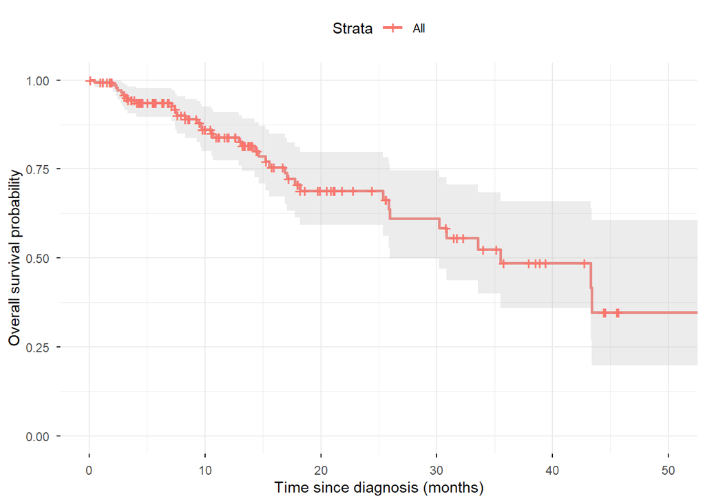

```r
# Create survival object using months as the time scale
surv_obj <- Surv(time = gec_surv$surv_time_mo, event = gec_surv$event)

# Fit overall KM curve
km_overall <- survfit(surv_obj ~ 1, data = gec_surv)

# Plot overall KM curve
ggsurvplot(
km_overall,
data = gec_surv,
conf.int = TRUE,
pval = FALSE,
xlab = "Time since diagnosis (months)",
ylab = "Overall survival probability",
ggtheme = theme_minimal()
)
```

## Interpretation of Overall KM curve

At diagnosis, overall survival starts at 1.0 and declines over time, with the steepest drop in the first 2–3 years after diagnosis.  
The survival curve crosses 0.50 at roughly **36 months**, suggesting a median overall survival of about 3 years in this cohort.  
Many censoring marks appear throughout follow-up, and the grey confidence band widens after ~30–35 months, indicating increasing uncertainty in the survival estimates at longer times.

### KM curves by race (White vs Black)

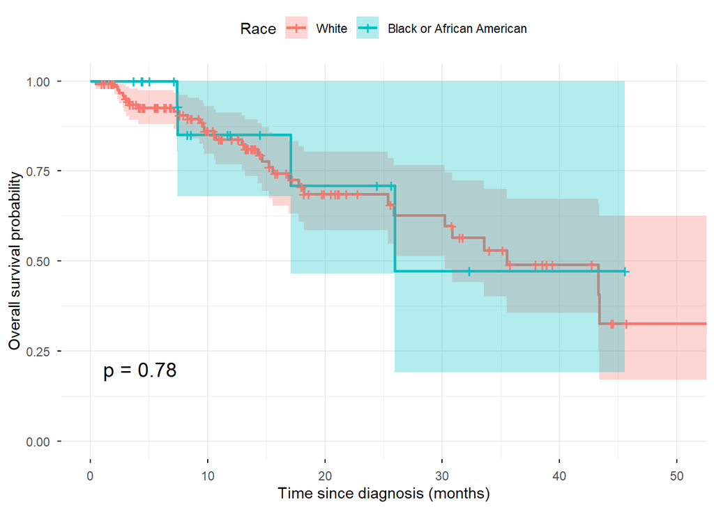

```r
# KM curves by race (White vs Black)
gec_surv_race <- gec_surv %>%
filter(race_f != "Unknown") %>%
mutate(race_f = droplevels(race_f))

# Fit KM curves by race
km_race <- survfit(
Surv(surv_time_mo, event) ~ race_f,
data = gec_surv_race
)

# Plot KM curves by race
ggsurvplot(
km_race,
data = gec_surv_race,
conf.int = TRUE,
pval = TRUE,
xlab = "Time since diagnosis (months)",
ylab = "Overall survival probability",
legend.title = "Race",
legend.labs = levels(gec_surv_race$race_f), # now length = 2
ggtheme = theme_minimal()
)
```

### Interpretation of KM curves by race (White vs Black)

When I compared KM curves for White vs Black patients, the curves overlapped substantially and the log-rank test was not statistically significant (p ≈ 0.78). The estimated median survival appeared somewhat shorter for Black patients than for White patients, but the confidence bands were wide and the small number of Black patients and deaths makes it hard to draw firm conclusions. Overall, I did not find strong evidence of racial differences in overall survival in this cohort.

### KM curves by sex

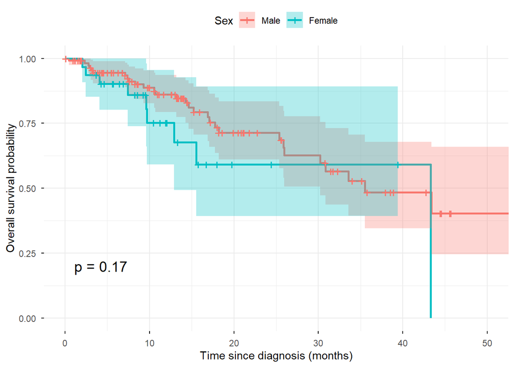

```r
# KM curves by sex
km_sex <- survfit(
Surv(surv_time_mo, event) ~ sex_f,
data = gec_surv
)

# Plot KM curves by sex
ggsurvplot(
km_sex,
data = gec_surv,
conf.int = TRUE,
pval = TRUE,
xlab = "Time since diagnosis (months)",
ylab = "Overall survival probability",
legend.title = "Sex",
legend.labs = levels(gec_surv$sex_f),
ggtheme = theme_minimal()
)
```

### Interpretation of KM curves by sex

KM curves for males and females also showed some visual differences, but the log-rank test was not statistically significant (p ≈ 0.17). Female patients’ survival curve dropped earlier and then remained fairly flat, while the male curve declined more gradually. Given the small sample size and few events in females, these patterns are unstable and should be interpreted cautiously.

### Cox PH model (survival ~ race + sex + covariates)

```r
# Recreate early vs late clinical stage in my survival dataset
gec_surv <- gec_surv %>%
mutate(
stage_late = case_when(
stage_f %in% c("Stage I", "Stage II") ~ 0, # early stage
stage_f %in% c("Stage III", "Stage IV") ~ 1, # late stage
TRUE ~ NA_real_ # keep unknown/missing as NA
),
stage_late = factor(
stage_late,
levels = c(0, 1),
labels = c("Early stage (I–II)", "Late stage (III–IV)")
)
)

# Create analytic dataset for Cox models for my ADA final project
# (keep White and Black, drop Unknown race)
gec_surv_cox <- gec_surv %>%
filter(
race_f %in% c("White", "Black or African American"),
!is.na(stage_late)
)
```

### Multivariable Cox model with race, sex, age, and stage:

```r
# Multivariable Cox proportional hazards model for my ADA final project
# Outcome: overall survival time (months) and death event
# Key predictors: race_f, sex_f
# Covariates: age at diagnosis, late vs early stage at diagnosis
cox_model <- coxph(
Surv(surv_time_mo, event) ~ race_f + sex_f + age + stage_late,
data = gec_surv_cox
)

summary(cox_model)
```

```
## Call:
## coxph(formula = Surv(surv_time_mo, event) ~ race_f + sex_f +
##     age + stage_late, data = gec_surv_cox)
##
##   n= 137, number of events= 35
##
##                                     coef exp(coef) se(coef)      z Pr(>|z|)
## race_fBlack or African American -0.20415   0.81534  0.53718 -0.380   0.7039
## race_fUnknown                         NA        NA  0.00000     NA       NA
## sex_fFemale                      0.70537   2.02459  0.43300  1.629   0.1033
## age                              0.01630   1.01644  0.01582  1.031   0.3027
## stage_lateLate stage (III–IV)    1.94355   6.98352  1.01589  1.913   0.0557 .
## ---
## Signif. codes:  0 '***' 0.001 '**' 0.01 '*' 0.05 '.' 0.1 ' ' 1
##
##                                 exp(coef) exp(-coef) lower .95 upper .95
## race_fBlack or African American    0.8153     1.2265    0.2845     2.337
## race_fUnknown                          NA         NA        NA        NA
## sex_fFemale                        2.0246     0.4939    0.8665     4.731
## age                                1.0164     0.9838    0.9854     1.048
## stage_lateLate stage (III–IV)      6.9835     0.1432    0.9536    51.145
##
## Concordance= 0.624  (se = 0.047 )
## Likelihood ratio test= 9.76  on 4 df,   p=0.04
## Wald test            = 6.58  on 4 df,   p=0.2
## Score (logrank) test = 7.86  on 4 df,   p=0.1
```

### Hazard ratios with 95% CIs:

```r
# Tidy Cox model output with hazard ratios (HR) and 95% CI
cox_results <- broom::tidy(
cox_model,
exponentiate = TRUE,
conf.int = TRUE
)

cox_results
```

```
## # A tibble: 5 × 7
##   term                   estimate std.error statistic p.value conf.low conf.high
##   <chr>                     <dbl>     <dbl>     <dbl>   <dbl>    <dbl>     <dbl>
## 1 race_fBlack or Africa…    0.815    0.537     -0.380  0.704     0.285      2.34
## 2 race_fUnknown            NA        0         NA     NA        NA         NA
## 3 sex_fFemale               2.02     0.433      1.63   0.103     0.866      4.73
## 4 age                       1.02     0.0158     1.03   0.303     0.985      1.05
## 5 stage_lateLate stage …    6.98     1.02       1.91   0.0557    0.954     51.1
```

### Interpretation of multivariable Cox model (HRs and 95% CIs)

In the Cox model adjusting for race, sex, age, and stage at diagnosis:

- **Race (Black vs White)**: HR ~0.82 (95% CI ~0.28–2.34, p ≈ 0.70), suggesting no clear difference in hazard of death by race.
- **Sex (Female vs Male)**: HR ~2.02 (95% CI ~0.87–4.73, p ≈ 0.10). Female patients had roughly twice the hazard of death compared with males, but the CI is wide and includes 1, so this was not statistically significant.
- **Age**: HR ~1.02 per year (95% CI ~0.99–1.05, p ≈ 0.30), indicating no strong association between age and survival after adjustment.
- **Stage at diagnosis (late vs early)**: HR ~6.98 (95% CI ~0.95–51.14, p ≈ 0.06). Patients diagnosed at late stage had much higher hazards of death than those diagnosed at early stage, and although the CI is wide and the p-value is just above 0.05, this is clinically consistent with more advanced disease having worse outcomes.

### Cox PH assumption

```r
# Check proportional hazards assumption for my Cox model
cox_ph_test <- cox.zph(cox_model)
cox_ph_test
```

```
##              chisq df    p
## race_f     0.00125  1 0.97
## sex_f      0.23323  1 0.63
## age        1.88550  1 0.17
## stage_late 0.19953  1 0.66
## GLOBAL     2.11676  4 0.71
```

### Interpretation of proportional hazards (PH) assumption check

For each covariate, the cox.zph test p-values were > 0.05 (race p = 0.97, sex p = 0.63, age p = 0.17, stage p = 0.66).The global PH test was also non-significant (χ² = 2.12, df = 4, p = 0.71). Taken together, there is no strong evidence of violation of the proportional hazards assumption for this Cox model, so the PH assumption appears reasonable for the analysis.

### Table 3: Multivariable Cox proportional hazards model for overall survival

```r
# using my cox_results object for my ADA final project
cox_table <- cox_results %>%

# drop intercept if present
dplyr::filter(term != "(Intercept)", !is.na(estimate)) %>%

# make readable labels for predictors
dplyr::mutate(
Predictor = dplyr::recode(
term,
"race_fBlack or African American" = "Race: Black vs White",
"sex_fFemale" = "Sex: Female vs Male",
"age" = "Age (per year)",
"stage_lateLate stage (III–IV)" = "Stage at diagnosis: Late (III–IV) vs Early (I–II)"
),
HR = round(estimate, 2),
CI = paste0(round(conf.low, 2), "-", round(conf.high, 2)),
p_value = round(p.value, 3)
) %>%
dplyr::select(Predictor, HR, CI, p_value)

knitr::kable(
cox_table,
caption = "Table 3. Multivariable Cox proportional hazards model for overall survival."
)
```

Table 3. Multivariable Cox proportional hazards model for overall survival.

| Predictor | HR | CI | p_value |
| --- | --- | --- | --- |
| Race: Black vs White | 0.82 | 0.28-2.34 | 0.704 |
| Sex: Female vs Male | 2.02 | 0.87-4.73 | 0.103 |
| Age (per year) | 1.02 | 0.99-1.05 | 0.303 |
| Stage at diagnosis: Late (III–IV) vs Early (I–II) | 6.98 | 0.95-51.14 | 0.056 |

# Discussion

In this ADA final project, I used a retrospective cohort of 150 patients with GEC treated at Siteman Cancer Center to explore race and sex differences in stage at diagnosis and overall survival. In descriptive analyses, most patients were male and White, with a high prevalence of tobacco use and a large proportion diagnosed at stage III–IV.

In both univariable and multivariable logistic regression models, I did not find strong evidence that race or sex were associated with late-stage diagnosis. The only statistically significant predictor of late stage was unknown *H. pylori* status, which likely reflects patterns of missing data or incomplete testing rather than a true causal effect.

**Limitations**

- The sample size was small, especially for Black and female patients, resulting in low statistical power and wide confidence intervals.
- This was a single-center cohort, which may limit generalizability to other settings.
- Several variables had substantial missing or “unknown” categories (e.g., *H. pylori* status, Barrett’s esophagus), which may introduce bias.
- I did not adjust for other important clinical factors such as comorbidities, performance status, or detailed treatment sequencing, which could confound associations between race/sex and outcomes.

**Implications and next steps**

Although I did not find strong evidence of racial or sex disparities in this small cohort, the analysis primarily shows how limited power and missing data can influence estimates. In future work, I would like to:

- Expand the cohort to include more patients and longer follow-up,
- Incorporate additional covariates (e.g., comorbidities, treatment patterns, biomarkers), and
- Use more flexible modeling approaches to better understand potential inequities in stage at diagnosis and survival.

This project helped me practice the full workflow from data cleaning and recoding to regression modeling and survival analysis using R Markdown.